# LDA/QDA:Use the k-fold cross validation to assess the performance of lda/qda on the wines dataset.

# Loading dataset and necessary library

```r
table(wines$quality)
```

```
##
##   3   4   5   6   7   8
##  10  53 681 638 199  18
```

# Categorizing each variable (Supplying categorical variables)

For the target attribute we will create categorical variable with two different values good and bad, so we have binary classification problem. I have categorised the target variable “quality” to two different values: 1: “good” if the original value of this attribute is bigger than 5 2: “bad” if the original value of this attribute is less than or equal 5

```r
winesb <- wines
winesb$quality <- factor(ifelse(wines$quality > 5, "good", "bad"))
table(wines$quality)
```

```
##
##   3   4   5   6   7   8
##  10  53 681 638 199  18
```

```r
rf<- randomForest(quality~., data = winesb, importance=TRUE)
importance(rf)
```

```
##                           bad     good MeanDecreaseAccuracy
## fixed.acidity        23.27976 25.73751             35.84922
## volatile.acidity     38.31322 32.85446             47.05103
## citric.acid          20.78762 23.22408             30.86799
## residual.sugar       20.21491 22.44266             29.08541
## chlorides            27.78642 23.98665             35.35394
## free.sulfur.dioxide  22.52810 24.83642             33.41461
## total.sulfur.dioxide 32.68257 39.09236             50.56380
## density              23.65414 30.44186             39.30972
## pH                   23.06947 25.13295             35.33823
## sulphates            46.24569 50.69549             63.38511
## alcohol              55.03195 53.04277             70.75453
##                      MeanDecreaseGini
## fixed.acidity                54.32753
## volatile.acidity             87.16055
## citric.acid                  51.55459
## residual.sugar               44.87135
## chlorides                    59.00179
## free.sulfur.dioxide          46.23075
## total.sulfur.dioxide         80.97948
## density                      70.77064
## pH                           53.25915
## sulphates                   102.59107
## alcohol                     144.64751
```

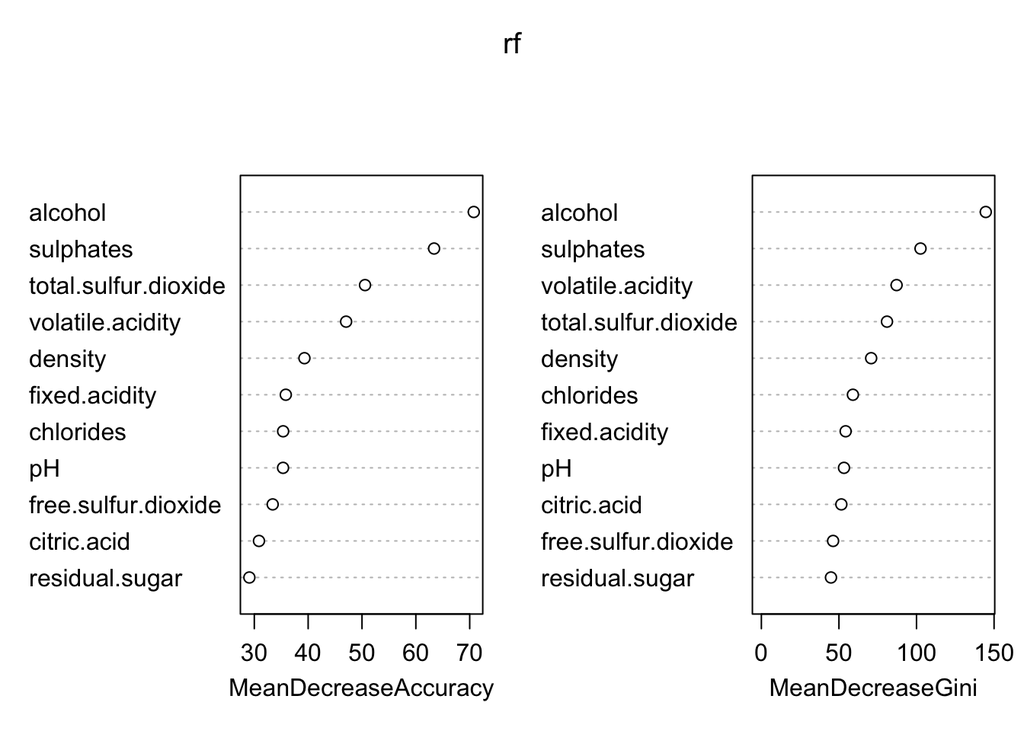

```r
varImpPlot(rf)
```

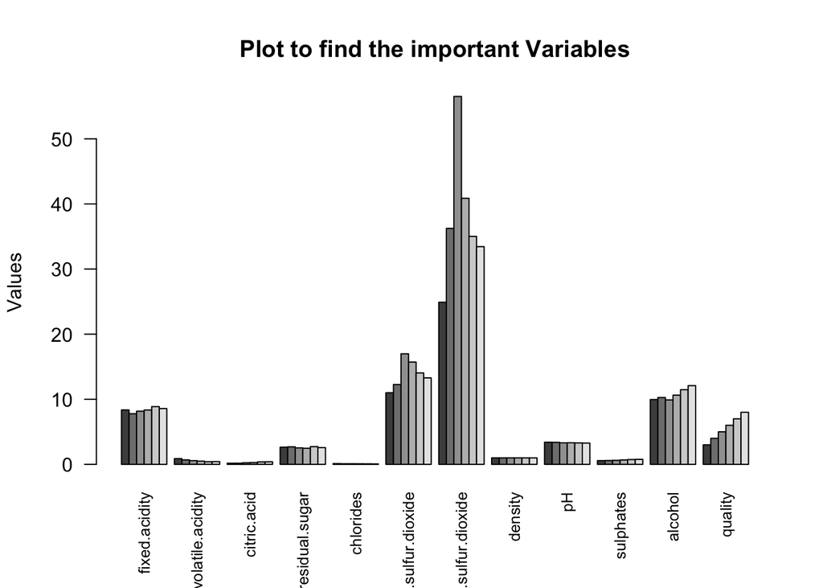

```r
mns = aggregate(wines,wines['quality'],mean)
rownames(mns) = mns$quality
mns$quality = NULL
barplot(as.matrix(mns),beside=TRUE,cex.names=.8,las=2,main="Plot to find the important Variables",ylab="Values")
```

The first model contains the first four important variables quality ~ alcohol + sulphates + total.sulfur.dioxide + volatile.acidity, while the second contains all variables In both cases we will train on the training dataset and test on the testing dataset then compare between these classifiers.

```r
indxTrain <- createDataPartition(y = winesb$quality, p = 0.8)
winesDataSetTrain<- winesb[indxTrain$Resample1,]
winesDataSetTest <- winesb[-indxTrain$Resample1,]
```

# K-Fold cross validation

```r
train_control <- trainControl(method="cv", number=10)
```

# Training the model

Done in more automatic way (by using ‘Caret’ package)

```r
model <- train(quality~., data=winesb, trControl=train_control, method="nb")
predictions <- predict(model, winesb)
confusionMatrix(predictions, winesb$quality)
```

```
## Confusion Matrix and Statistics
##
##           Reference
## Prediction bad good
##       bad  596  228
##       good 148  627
##
##                Accuracy : 0.7649
##                  95% CI : (0.7433, 0.7855)
##     No Information Rate : 0.5347
##     P-Value [Acc > NIR] : < 2.2e-16
##
##                   Kappa : 0.5307
##  Mcnemar's Test P-Value : 4.619e-05
##
##             Sensitivity : 0.8011
##             Specificity : 0.7333
##          Pos Pred Value : 0.7233
##          Neg Pred Value : 0.8090
##              Prevalence : 0.4653
##          Detection Rate : 0.3727
##    Detection Prevalence : 0.5153
##       Balanced Accuracy : 0.7672
##
##        'Positive' Class : bad
##
```

# Linear discriminant analysis (LDA)

It groups follow Gaussian distribution which has the same structure of variance-covarianceand it has a difference in means.

```r
lda.model <- lda(quality~., data=winesb)
lda.model
```

```
## Call:
## lda(quality ~ ., data = winesb)
##
## Prior probabilities of groups:
##       bad      good
## 0.4652908 0.5347092
##
## Group means:
##      fixed.acidity volatile.acidity citric.acid residual.sugar  chlorides
## bad       8.142204        0.5895027   0.2377554       2.542070 0.09298925
## good      8.474035        0.4741462   0.2998830       2.535965 0.08266082
##      free.sulfur.dioxide total.sulfur.dioxide   density       pH sulphates
## bad             16.56720             54.64516 0.9970685 3.311653 0.6185349
## good            15.27251             39.35205 0.9964666 3.310643 0.6926199
##        alcohol
## bad   9.926478
## good 10.855029
##
## Coefficients of linear discriminants:
##                               LD1
## fixed.acidity          0.10216398
## volatile.acidity      -2.48086974
## citric.acid           -0.83101053
## residual.sugar         0.03414600
## chlorides             -3.42366635
## free.sulfur.dioxide    0.01958093
## total.sulfur.dioxide  -0.01381546
## density              -33.49776954
## pH                    -0.29863294
## sulphates              2.24940833
## alcohol                0.67194919
```

```r
lda.pred <- predict(lda.model, winesb)
names(lda.pred)
```

```
## [1] "class"     "posterior" "x"
```

```r
table(predicted = lda.pred$class, real = winesb$quality)
```

```
##          real
## predicted bad good
##      bad  555  218
##      good 189  637
```

# For the first model we do LDA/QDA only for the most important variables got on the training set. We see that QDA performance is better than LDA.

```r
mat <- sapply(c('lda', 'qda'), function (met) {
  modelFit<- train(quality~alcohol + sulphates + total.sulfur.dioxide + volatile.acidity, method=met,preProcess=c('scale', 'center'), data=winesDataSetTrain, trControl=train_control)
  confusionMatrix(winesDataSetTest$quality, predict(modelFit, winesDataSetTest))$overall
})

round(mat*100,2)
```

```
##                  lda   qda
## Accuracy       77.74 78.68
## Kappa          55.44 57.22
## AccuracyLower  72.77 73.78
## AccuracyUpper  82.19 83.05
## AccuracyNull   50.78 52.35
## AccuracyPValue  0.00  0.00
## McnemarPValue  34.24 71.60
```

# For the second model we do LDA/QDA for all the variables on the training set. We see that LDA performance is better than QDA.

```r
mat2 <- sapply(c('lda', 'qda'), function (met) {
  modelFit<- train(quality~., method=met,preProcess=c('scale', 'center'), data=winesDataSetTrain, trControl=train_control)
  confusionMatrix(winesDataSetTest$quality, predict(modelFit, winesDataSetTest))$overall
})
round(mat2*100,2)
```

```
##                  lda   qda
## Accuracy       80.25 75.55
## Kappa          60.35 50.30
## AccuracyLower  75.45 70.45
## AccuracyUpper  84.48 80.17
## AccuracyNull   52.66 61.13
## AccuracyPValue  0.00  0.00
## McnemarPValue  80.11  0.92
```

# For the whole data set, all the variables. Here we see that the performance is almost the same.

```r
mat3 <- sapply(c('lda', 'qda'), function (met) {
  modelFit<- train(quality~., method=met,preProcess=c('scale', 'center'), data=winesb, trControl=train_control)
  confusionMatrix(winesb$quality, predict(modelFit, winesb))$overall
})

round(mat3*100,2)
```

```
##                  lda   qda
## Accuracy       74.55 74.42
## Kappa          48.98 48.21
## AccuracyLower  72.34 72.21
## AccuracyUpper  76.67 76.54
## AccuracyNull   51.66 58.79
## AccuracyPValue  0.00  0.00
## McnemarPValue  16.52  0.00
```

# Conclusions